# dsc478 _finalProject_Clustering

## Importing and cleaning dataset

```python
pip install kneed
```

```python
import pandas as pd
import numpy as np
import matplotlib.pyplot as plt
import matplotlib.pyplot as plt
from kneed import KneeLocator
from sklearn.datasets import make_blobs
from sklearn.cluster import KMeans
from sklearn.metrics import silhouette_score
from sklearn.preprocessing import StandardScaler
```

```python
df = pd.read_csv("/Users/AlexMischou/Desktop/programming machine learning/healthcare-dataset-stroke-data.csv")
df

print(df.describe(), '\n\n', df.describe(include='object'))
```

```
                 id          age  hypertension  heart_disease  \
count   5110.000000  5110.000000   5110.000000    5110.000000
mean   36517.829354    43.226614      0.097456       0.054012
std    21161.721625    22.612647      0.296607       0.226063
min       67.000000     0.080000      0.000000       0.000000
25%    17741.250000    25.000000      0.000000       0.000000
50%    36932.000000    45.000000      0.000000       0.000000
75%    54682.000000    61.000000      0.000000       0.000000
max    72940.000000    82.000000      1.000000       1.000000

       avg_glucose_level          bmi       stroke
count        5110.000000  4909.000000  5110.000000
mean          106.147677    28.893237     0.048728
std            45.283560     7.854067     0.215320
min            55.120000    10.300000     0.000000
25%            77.245000    23.500000     0.000000
50%            91.885000    28.100000     0.000000
75%           114.090000    33.100000     0.000000
max           271.740000    97.600000     1.000000

         gender ever_married work_type Residence_type smoking_status
count     5110         5110      5110           5110           5110
unique       3            2         5              2              4
top     Female          Yes   Private          Urban   never smoked
freq      2994         3353      2925           2596           1892
```

```python
len(df)
```

```
5110
```

There are some null values in the BMI category. I am replacing them with the mean.

```python
#replacing null bmi values with the mean
df['bmi'].fillna((df['bmi'].mean()),inplace=True)
```

```python
df.isnull().sum()
```

[output not shown]

Visualizing the data before scaling - there is a varied range between the continuous variables. I'm going to use scatter plots to see if my continuous variables are related.

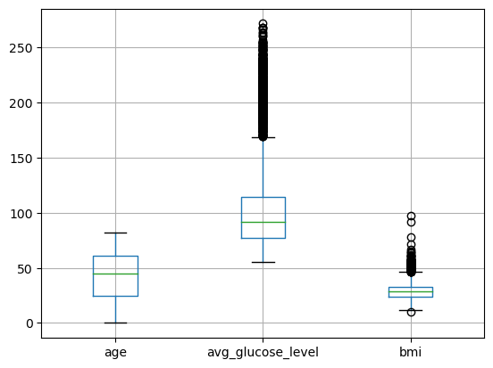

```python
df.boxplot(column=["age","avg_glucose_level","bmi"], return_type='axes')
```

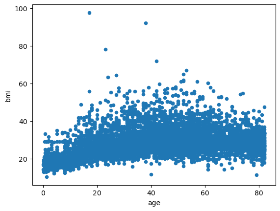

```python
df.plot(x="age", y="bmi", kind="scatter")
plt.show()
```

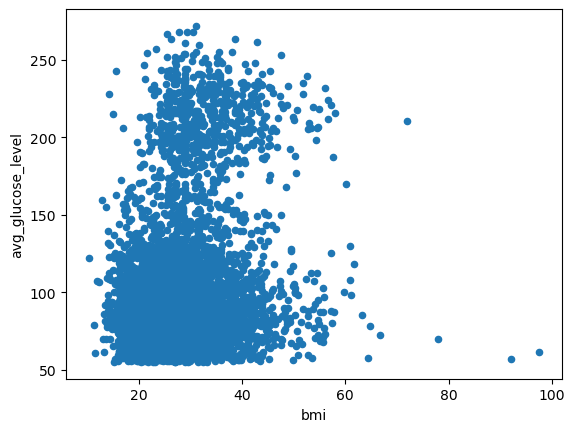

```python
df.plot(x="bmi", y="avg_glucose_level", kind="scatter")
plt.show()
```

Not really a correlation. Casting hypertension, heart disease, and stoke to yes/no in order to make the dummy variable names easier to read. Then I am creating dummy variables.

```python
ht = []
hd = []
st= []

for i in range(len(df)):
    if df['hypertension'][i] == 0:
        val1 ='no'
    else:
        val1 = 'yes'

    if df['heart_disease'][i] == 0:
        val2='no'
    else:
        val2 = 'yes'

    if df['stroke'][i] == 0:
        val3='no'
    else:
        val3 = 'yes'

    ht.append(val1)
    hd.append(val2)
    st.append(val3)

df['ht'] = ht
df['hd'] = hd
df['st'] = st
```

```python
df.head()
```

|  | id | gender | age | hypertension | heart_disease | ever_married | work_type | Residence_type | avg_glucose_level | bmi | smoking_status | stroke | ht | hd | st |
| --- | --- | --- | --- | --- | --- | --- | --- | --- | --- | --- | --- | --- | --- | --- | --- |
| 0 | 9046 | Male | 67.0 | 0 | 1 | Yes | Private | Urban | 228.69 | 36.600000 | formerly smoked | 1 | no | yes | yes |
| 1 | 51676 | Female | 61.0 | 0 | 0 | Yes | Self-employed | Rural | 202.21 | 28.893237 | never smoked | 1 | no | no | yes |
| 2 | 31112 | Male | 80.0 | 0 | 1 | Yes | Private | Rural | 105.92 | 32.500000 | never smoked | 1 | no | yes | yes |
| 3 | 60182 | Female | 49.0 | 0 | 0 | Yes | Private | Urban | 171.23 | 34.400000 | smokes | 1 | no | no | yes |
| 4 | 1665 | Female | 79.0 | 1 | 0 | Yes | Self-employed | Rural | 174.12 | 24.000000 | never smoked | 1 | yes | no | yes |

```python
dataset = pd.get_dummies(df)
```

```python
dataset.head()
```

|  | id | age | hypertension | heart_disease | avg_glucose_level | bmi | stroke | gender_Female | gender_Male | gender_Other | ... | smoking_status_Unknown | smoking_status_formerly smoked | smoking_status_never smoked | smoking_status_smokes | ht_no | ht_yes | hd_no | hd_yes | st_no | st_yes |
| --- | --- | --- | --- | --- | --- | --- | --- | --- | --- | --- | --- | --- | --- | --- | --- | --- | --- | --- | --- | --- | --- |
| 0 | 9046 | 67.0 | 0 | 1 | 228.69 | 36.600000 | 1 | 0 | 1 | 0 | ... | 0 | 1 | 0 | 0 | 1 | 0 | 0 | 1 | 0 | 1 |
| 1 | 51676 | 61.0 | 0 | 0 | 202.21 | 28.893237 | 1 | 1 | 0 | 0 | ... | 0 | 0 | 1 | 0 | 1 | 0 | 1 | 0 | 0 | 1 |
| 2 | 31112 | 80.0 | 0 | 1 | 105.92 | 32.500000 | 1 | 0 | 1 | 0 | ... | 0 | 0 | 1 | 0 | 1 | 0 | 0 | 1 | 0 | 1 |
| 3 | 60182 | 49.0 | 0 | 0 | 171.23 | 34.400000 | 1 | 1 | 0 | 0 | ... | 0 | 0 | 0 | 1 | 1 | 0 | 1 | 0 | 0 | 1 |
| 4 | 1665 | 79.0 | 1 | 0 | 174.12 | 24.000000 | 1 | 1 | 0 | 0 | ... | 0 | 0 | 1 | 0 | 0 | 1 | 1 | 0 | 0 | 1 |

5 rows × 29 columns

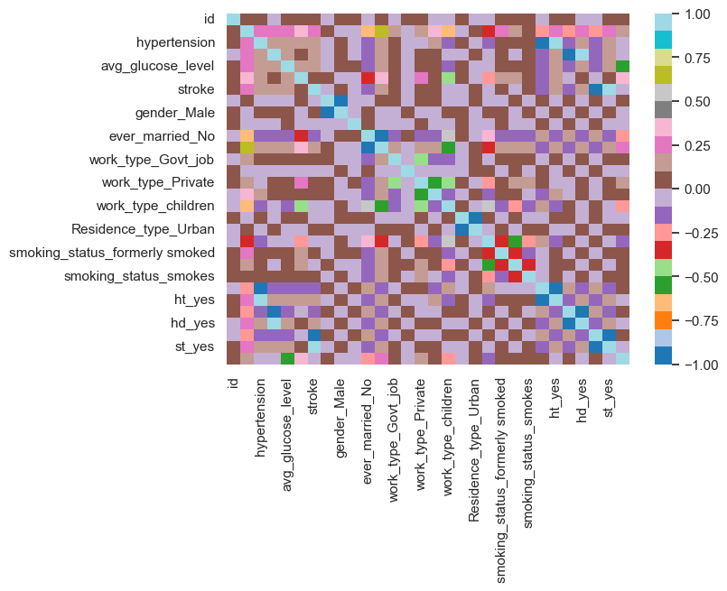

```python
M = dataset.corr()
ax = sns.heatmap(M, cmap='tab20')
```

splitting into labels and features:

```python
labels = dataset['stroke']
features = dataset[['age','avg_glucose_level','bmi']]
```

```python
features.head()
#labels.head()
```

|  | age | avg_glucose_level | bmi |
| --- | --- | --- | --- |
| 0 | 67.0 | 228.69 | 36.600000 |
| 1 | 61.0 | 202.21 | 28.893237 |
| 2 | 80.0 | 105.92 | 32.500000 |
| 3 | 49.0 | 171.23 | 34.400000 |
| 4 | 79.0 | 174.12 | 24.000000 |

```python
corr_matrix = features.corr() #checking correlation with a corrPlot
corr_matrix
```

|  | age | avg_glucose_level | bmi |
| --- | --- | --- | --- |
| age | 1.000000 | 0.238171 | 0.325942 |
| avg_glucose_level | 0.238171 | 1.000000 | 0.168751 |
| bmi | 0.325942 | 0.168751 | 1.000000 |

Standard scaler scales so by feature the mean of my data is 0 and the standard deviation is 1. It basically standardizes the data to a bell curve.

```python
scaler = StandardScaler()
scaled_features = scaler.fit_transform(features)
```

```python
scaled_features
```

```
array([[ 1.05143428e+00,  2.70637544e+00,  1.00123401e+00],
       [ 7.86070073e-01,  2.12155854e+00,  1.38466607e-15],
       [ 1.62639008e+00, -5.02830130e-03,  4.68577254e-01],
       ...,
       [-3.63841511e-01, -5.11442636e-01,  2.21736316e-01],
       [ 3.43796387e-01,  1.32825706e+00, -4.27845098e-01],
       [ 3.42048064e-02, -4.60867458e-01, -3.49895329e-01]])
```

## clustering using kMeans

```python
kmeans = KMeans(init='random',n_clusters=4,n_init=10,max_iter=300,random_state=42)
```

```python
kmeans.fit(scaled_features)
```

```
KMeans(init='random', n_clusters=4, random_state=42)
```

```python
kmeans.inertia_
```

```
5142.392011610783
```

```python
centroids = kmeans.cluster_centers_
centroids
```

```
array([[ 0.76435128,  2.23226832,  0.51183767],
       [-1.12154252, -0.29706534, -0.78882488],
       [ 0.73765619, -0.36792543, -0.13905645],
       [-0.07976572, -0.34949601,  1.33000787]])
```

```python
kmeans.n_iter_
```

```
8
```

```python
kmeans.labels_
```

```
array([0, 0, 2, ..., 3, 0, 2], dtype=int32)
```

```python
kmeans_kwargs = {"init":"random", "n_init": 10, "max_iter":300,"random_state":42}
```

```python
sse = []
for k in range(1,11):
    kmeans = KMeans(n_clusters=k, **kmeans_kwargs)
    kmeans.fit(scaled_features)
    sse.append(kmeans.inertia_)
```

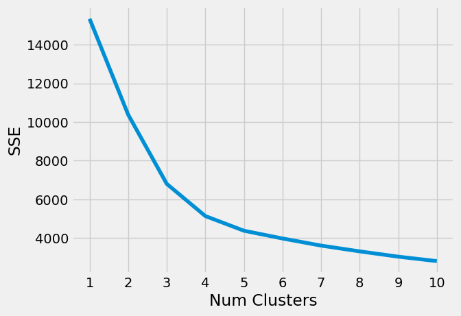

```python
plt.style.use('fivethirtyeight')
plt.plot(range(1,11), sse)
plt.xticks(range(1,11))
plt.xlabel('Num Clusters')
plt.ylabel('SSE')
plt.show()
```

Using both the elbow method and silhouette, I can see that the optimal number of clusters is four to minimize the sum of squared errors and maximize consistency within the clusters.

```python
kl = KneeLocator(range(1,11),sse,curve='convex',direction='decreasing')
kl.elbow
```

```
4
```

```python
silhouette_coefficients = []

for k in range(2,11):
    kmeans = KMeans(n_clusters=k, **kmeans_kwargs)
    kmeans.fit(scaled_features)
    score = silhouette_score(scaled_features, kmeans.labels_)
    silhouette_coefficients.append(score)
```

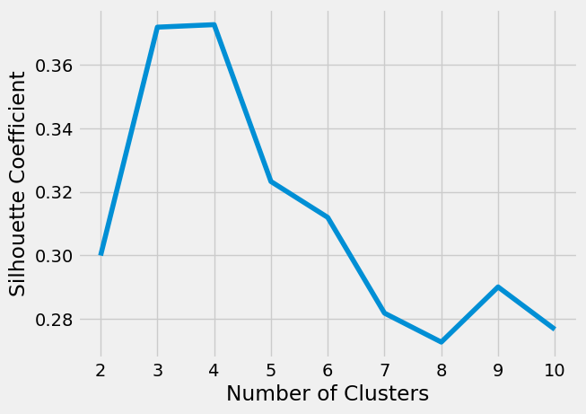

```python
plt.style.use('fivethirtyeight')
plt.plot(range(2,11), silhouette_coefficients)
plt.xticks(range(2,11))
plt.xlabel('Number of Clusters')
plt.ylabel('Silhouette Coefficient')
plt.show()
```

It looks like our first run with four clusters was already the best choice. I will visualize the clusters below:

```python
from sklearn.datasets import make_blobs
np.random.seed(0)
centers = centroids
n_clusters = len(centers)
X, labels_true = make_blobs(n_samples=5110,centers=centers,cluster_std=0.2)
```

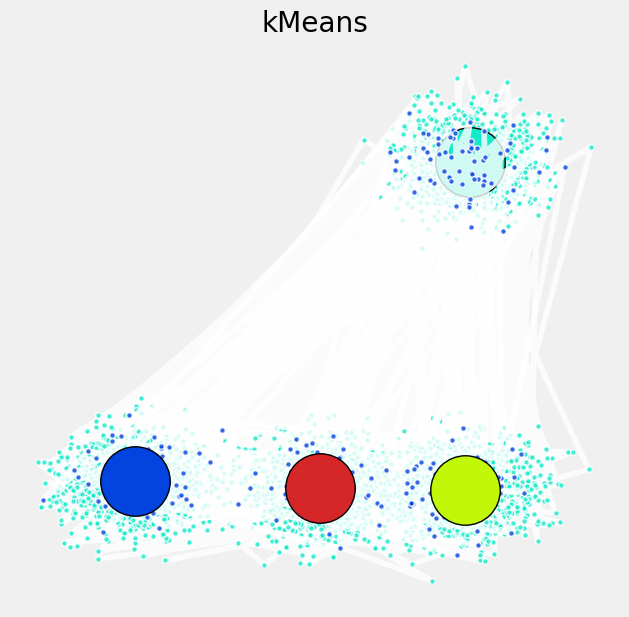

```python
fig = plt.figure(figsize=(7,7))
colors = ['#13EAC9', '#0343DF', '#C1F80A', '#d62728', '#9467bd', '#8c564b','#e377c2']

for k, col in zip(range(n_clusters),colors):
    my_members = labels == k
    cluster_center = centers[k]
    plt.plot(X[my_members,0],X[my_members,1], "w",markerfacecolor=col,
            marker=".",markersize=8, alpha=0.8)
    plt.plot(
        cluster_center[0],
        cluster_center[1],
        "o",
        markerfacecolor=col,
        markeredgecolor='black',
        alpha=1,
        markersize=50
    )

plt.title("kMeans")
plt.xticks(())
plt.yticks(())
plt.show()
```

What features did the clusters maximize on?

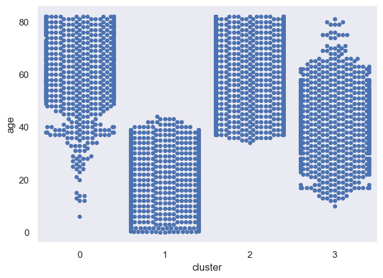

```python
dataset['cluster']=kmeans.labels_
sns.swarmplot(x=dataset.cluster,y=dataset.age)
```

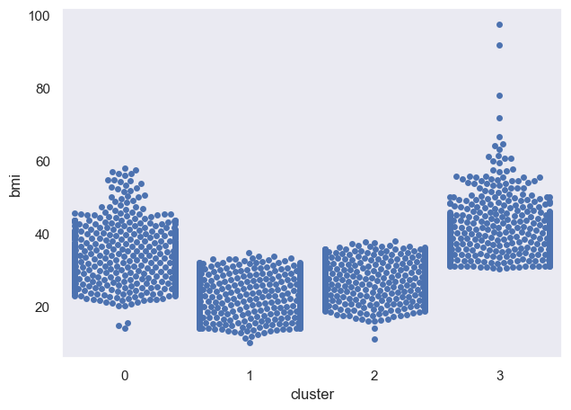

```python
sns.swarmplot(x=dataset.cluster,y=dataset.bmi)
```

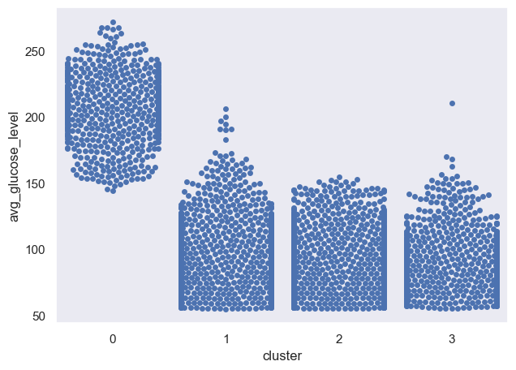

```python
sns.swarmplot(x=dataset.cluster,y=dataset.avg_glucose_level)
```

```python
print("What clusters were most likely to contain stroke_yes? \n" , dataset.groupby(['cluster','st_yes']).describe())
```

```
What clusters were most likely to contain stroke_yes?
                     id                                                 \
                 count          mean           std      min       25%
cluster st_yes
0       0        583.0  37084.048027  21046.094013    239.0  17792.00
        1         89.0  38756.977528  21708.140977   1210.0  20387.00
1       0       1633.0  36094.510104  20900.545395     67.0  17492.00
        1          4.0  47767.250000  16399.886572  31720.0  37864.00
2       0       1751.0  36259.587664  21287.534759     84.0  17372.50
        1        141.0  35427.262411  22601.689803    210.0  14248.00
3       0        894.0  37261.278523  21244.492025     99.0  18888.75
        1         15.0  40397.866667  18725.241783  12095.0  27918.00

                                               age             ... hd_yes  \
                    50%       75%      max   count       mean  ...    75%
cluster st_yes                                                 ...
0       0       37713.0  54335.50  72915.0   583.0  59.193825  ...    0.0
        1       39373.0  58267.00  71279.0    89.0  69.123596  ...    1.0
1       0       36486.0  53998.00  72940.0  1633.0  17.859571  ...    0.0
        1       44790.5  54693.75  69768.0     4.0  21.330000  ...    0.0
2       0       36837.0  55180.00  72882.0  1751.0  59.140491  ...    0.0
        1       35512.0  54724.00  72918.0   141.0  69.375887  ...    0.0
3       0       37360.0  55443.00  72911.0   894.0  41.156600  ...    0.0
        1       36338.0  58272.00  66315.0    15.0  56.333333  ...    0.0

                      st_no
                max   count mean  std  min  25%  50%  75%  max
cluster st_yes
0       0       1.0   583.0  1.0  0.0  1.0  1.0  1.0  1.0  1.0
        1       1.0    89.0  0.0  0.0  0.0  0.0  0.0  0.0  0.0
1       0       1.0  1633.0  1.0  0.0  1.0  1.0  1.0  1.0  1.0
        1       0.0     4.0  0.0  0.0  0.0  0.0  0.0  0.0  0.0
2       0       1.0  1751.0  1.0  0.0  1.0  1.0  1.0  1.0  1.0
        1       1.0   141.0  0.0  0.0  0.0  0.0  0.0  0.0  0.0
3       0       1.0   894.0  1.0  0.0  1.0  1.0  1.0  1.0  1.0
        1       1.0    15.0  0.0  0.0  0.0  0.0  0.0  0.0  0.0

[8 rows x 224 columns]
```

## clustering with Bernoulli Mixture Model

I read that this can help with categorical data if you convert to dummy variables (binary) first, then run the mixture model. It creates a mixture of binary vectors that are supposed to represent a conditional distribution of 'x' or our feature. It uses probabilities as 'weights' for the clusters.

```python
from scipy.special import logsumexp

class BernoulliMixture:

    def __init__(self, n_components, max_iter, tol=1e-3):
        self.n_components = n_components
        self.max_iter = max_iter
        self.tol = tol

    def fit(self,x):
        self.x = x
        self.init_params()
        log_bernoullis = self.get_log_bernoullis(self.x)
        self.old_logL = self.get_log_likelihood(log_bernoullis)
        for step in range(self.max_iter):
            if step > 0:
                self.old_logL = self.logL
            # E-Step
            self.gamma = self.get_responsibilities(log_bernoullis)
            self.remember_params()
            # M-Step
            self.get_Neff()
            self.get_mu()
            self.get_pi()
            # Compute new log_likelihood:
            log_bernoullis = self.get_log_bernoullis(self.x)
            self.logL = self.get_log_likelihood(log_bernoullis)
            if np.isnan(self.logL):
                self.reset_params()
                print(self.logL)
                break

    def reset_params(self):
        self.mu = self.old_mu.copy()
        self.pi = self.old_pi.copy()
        self.gamma = self.old_gamma.copy()
        self.get_Neff()
        log_bernoullis = self.get_log_bernoullis(self.x)
        self.logL = self.get_log_likelihood(log_bernoullis)

    def remember_params(self):
        self.old_mu = self.mu.copy()
        self.old_pi = self.pi.copy()
        self.old_gamma = self.gamma.copy()

    def init_params(self):
        self.n_samples = self.x.shape[0]
        self.n_features = self.x.shape[1]
        #self.gamma = np.zeros(shape=(self.n_samples, self.n_components))
        self.pi = 1/self.n_components * np.ones(self.n_components)
        self.mu = np.random.RandomState(seed=0).uniform(low=0.25, high=0.75, size=(self.n_components, self.n_features))
        self.normalize_mu()

    def normalize_mu(self):
        sum_over_features = np.sum(self.mu, axis=1)
        for k in range(self.n_components):
            self.mu[k,:] /= sum_over_features[k]

    def get_responsibilities(self, log_bernoullis):
        gamma = np.zeros(shape=(log_bernoullis.shape[0], self.n_components))
        Z =  logsumexp(np.log(self.pi[None,:]) + log_bernoullis, axis=1)
        for k in range(self.n_components):
            gamma[:, k] = np.exp(np.log(self.pi[k]) + log_bernoullis[:,k] - Z)
        return gamma

    def get_log_bernoullis(self, x):
        log_bernoullis = self.get_save_single(x, self.mu)
        log_bernoullis += self.get_save_single(1-x, 1-self.mu)
        return log_bernoullis

    def get_save_single(self, x, mu):
        mu_place = np.where(np.max(mu, axis=0) <= 1e-15, 1e-15, mu)
        return np.tensordot(x, np.log(mu_place), (1,1))

    def get_Neff(self):
        self.Neff = np.sum(self.gamma, axis=0)

    def get_mu(self):
        self.mu = np.einsum('ik,id -> kd', self.gamma, self.x) / self.Neff[:,None]

    def get_pi(self):
        self.pi = self.Neff / self.n_samples

    def predict(self, x):
        log_bernoullis = self.get_log_bernoullis(x)
        gamma = self.get_responsibilities(log_bernoullis)
        return np.argmax(gamma, axis=1)

    def get_sample_log_likelihood(self, log_bernoullis):
        return logsumexp(np.log(self.pi[None,:]) + log_bernoullis, axis=1)

    def get_log_likelihood(self, log_bernoullis):
        return np.mean(self.get_sample_log_likelihood(log_bernoullis))

    def score(self, x):
        log_bernoullis = self.get_log_bernoullis(x)
        return self.get_log_likelihood(log_bernoullis)

    def score_samples(self, x):
        log_bernoullis = self.get_log_bernoullis(x)
        return self.get_sample_log_likelihood(log_bernoullis)
```

```python
labels = dataset['stroke']
features = dataset.drop(['age','avg_glucose_level','bmi','id','stroke'],axis=1)
```

```python
from sklearn.model_selection import train_test_split

X = features.values
x_train, x_test = train_test_split(X, shuffle=True, random_state=0)
```

```python
scores = []
components_to_test=[5,10,15,20,25,30,35,40,45,50]

for n in range(len(components_to_test)):
    if n > 0:
        old_score = score
    model = BernoulliMixture(components_to_test[n], 200)
    model.fit(x_train)
    score = model.score(x_test)
    scores.append(score)
    if n > 0:
        if score > old_score:
            estimated_components = components_to_test[n]
```

```
12.848674439698275
13.025149179285082
13.019207120379972
13.164125071886696
-31.773100247449257
-31.846095421498006
-31.855604833776116
-31.871897874141197
-31.809175367579584
-31.798437034234123
```

```python
estimated_components
```

```
50
```

```python
model = BernoulliMixture(estimated_components, 200)
model.fit(X)
```

```
-31.80379951306427
```

```python
compare=labels.copy()
predictions = np.argmax(model.gamma, axis=1)
preds = list(predictions)
compare['cluster'] = preds
compare
```

```
0                                                          1
1                                                          1
2                                                          1
3                                                          1
4                                                          1
                                 ...
5106                                                       0
5107                                                       0
5108                                                       0
5109                                                       0
cluster    [3, 2, 18, 43, 29, 20, 29, 40, 2, 43, 2, 24, 4...
Name: stroke, Length: 5111, dtype: object
```

```python
features['cluster'] = preds
features
```

|  | hypertension | heart_disease | gender_Female | gender_Male | gender_Other | ever_married_No | ever_married_Yes | work_type_Govt_job | work_type_Never_worked | work_type_Private | ... | smoking_status_formerly smoked | smoking_status_never smoked | smoking_status_smokes | ht_no | ht_yes | hd_no | hd_yes | st_no | st_yes | cluster |
| --- | --- | --- | --- | --- | --- | --- | --- | --- | --- | --- | --- | --- | --- | --- | --- | --- | --- | --- | --- | --- | --- |
| 0 | 0 | 1 | 0 | 1 | 0 | 0 | 1 | 0 | 0 | 1 | ... | 1 | 0 | 0 | 1 | 0 | 0 | 1 | 0 | 1 | 3 |
| 1 | 0 | 0 | 1 | 0 | 0 | 0 | 1 | 0 | 0 | 0 | ... | 0 | 1 | 0 | 1 | 0 | 1 | 0 | 0 | 1 | 2 |
| 2 | 0 | 1 | 0 | 1 | 0 | 0 | 1 | 0 | 0 | 1 | ... | 0 | 1 | 0 | 1 | 0 | 0 | 1 | 0 | 1 | 18 |
| 3 | 0 | 0 | 1 | 0 | 0 | 0 | 1 | 0 | 0 | 1 | ... | 0 | 0 | 1 | 1 | 0 | 1 | 0 | 0 | 1 | 43 |
| 4 | 1 | 0 | 1 | 0 | 0 | 0 | 1 | 0 | 0 | 0 | ... | 0 | 1 | 0 | 0 | 1 | 1 | 0 | 0 | 1 | 29 |
| ... | ... | ... | ... | ... | ... | ... | ... | ... | ... | ... | ... | ... | ... | ... | ... | ... | ... | ... | ... | ... | ... |
| 5105 | 1 | 0 | 1 | 0 | 0 | 0 | 1 | 0 | 0 | 1 | ... | 0 | 1 | 0 | 0 | 1 | 1 | 0 | 1 | 0 | 2 |
| 5106 | 0 | 0 | 1 | 0 | 0 | 0 | 1 | 0 | 0 | 0 | ... | 0 | 1 | 0 | 1 | 0 | 1 | 0 | 1 | 0 | 2 |
| 5107 | 0 | 0 | 1 | 0 | 0 | 0 | 1 | 0 | 0 | 0 | ... | 0 | 1 | 0 | 1 | 0 | 1 | 0 | 1 | 0 | 2 |
| 5108 | 0 | 0 | 0 | 1 | 0 | 0 | 1 | 0 | 0 | 1 | ... | 1 | 0 | 0 | 1 | 0 | 1 | 0 | 1 | 0 | 43 |
| 5109 | 0 | 0 | 1 | 0 | 0 | 0 | 1 | 1 | 0 | 0 | ... | 0 | 0 | 0 | 1 | 0 | 1 | 0 | 1 | 0 | 2 |

5110 rows × 25 columns

```python
from collections import Counter
print(Counter(preds).most_common(8))
features.groupby('cluster').describe()
```

```
[(2, 1765), (43, 1031), (5, 653), (48, 581), (6, 292), (33, 138), (40, 92), (23, 67)]
```

| cluster | hypertension count | hypertension mean | hypertension std | hypertension min | hypertension 25% | hypertension 50% | hypertension 75% | hypertension max | heart_disease count | heart_disease mean | ... | st_no 75% | st_no max | st_yes count | st_yes mean | st_yes std | st_yes min | st_yes 25% | st_yes 50% | st_yes 75% | st_yes max |
| --- | --- | --- | --- | --- | --- | --- | --- | --- | --- | --- | --- | --- | --- | --- | --- | --- | --- | --- | --- | --- | --- |
| 0 | 2.0 | 0.000000 | 0.000000 | 0.0 | 0.00 | 0.0 | 0.00 | 0.0 | 2.0 | 1.000000 | ... | 0.0 | 0.0 | 2.0 | 1.000000 | 0.000000 | 1.0 | 1.0 | 1.0 | 1.0 | 1.0 |
| 1 | 25.0 | 1.000000 | 0.000000 | 1.0 | 1.00 | 1.0 | 1.00 | 1.0 | 25.0 | 0.000000 | ... | 1.0 | 1.0 | 25.0 | 0.200000 | 0.408248 | 0.0 | 0.0 | 0.0 | 0.0 | 1.0 |
| 2 | 1765.0 | 0.060623 | 0.238706 | 0.0 | 0.00 | 0.0 | 0.00 | 1.0 | 1765.0 | 0.015864 | ... | 1.0 | 1.0 | 1765.0 | 0.037394 | 0.189779 | 0.0 | 0.0 | 0.0 | 0.0 | 1.0 |
| 3 | 9.0 | 0.000000 | 0.000000 | 0.0 | 0.00 | 0.0 | 0.00 | 0.0 | 9.0 | 0.666667 | ... | 0.0 | 0.0 | 9.0 | 1.000000 | 0.000000 | 1.0 | 1.0 | 1.0 | 1.0 | 1.0 |
| 4 | 33.0 | 0.484848 | 0.507519 | 0.0 | 0.00 | 0.0 | 1.00 | 1.0 | 33.0 | 0.000000 | ... | 1.0 | 1.0 | 33.0 | 0.060606 | 0.242306 | 0.0 | 0.0 | 0.0 | 0.0 | 1.0 |
| 5 | 653.0 | 0.176110 | 0.381206 | 0.0 | 0.00 | 0.0 | 0.00 | 1.0 | 653.0 | 0.000000 | ... | 1.0 | 1.0 | 653.0 | 0.038285 | 0.192030 | 0.0 | 0.0 | 0.0 | 0.0 | 1.0 |
| 6 | 292.0 | 0.000000 | 0.000000 | 0.0 | 0.00 | 0.0 | 0.00 | 0.0 | 292.0 | 0.078767 | ... | 1.0 | 1.0 | 292.0 | 0.006849 | 0.082618 | 0.0 | 0.0 | 0.0 | 0.0 | 1.0 |
| 7 | 8.0 | 1.000000 | 0.000000 | 1.0 | 1.00 | 1.0 | 1.00 | 1.0 | 8.0 | 0.000000 | ... | 1.0 | 1.0 | 8.0 | 0.000000 | 0.000000 | 0.0 | 0.0 | 0.0 | 0.0 | 0.0 |
| 8 | 14.0 | 0.500000 | 0.518875 | 0.0 | 0.00 | 0.5 | 1.00 | 1.0 | 14.0 | 0.571429 | ... | 1.0 | 1.0 | 14.0 | 0.500000 | 0.518875 | 0.0 | 0.0 | 0.5 | 1.0 | 1.0 |
| 9 | 6.0 | 1.000000 | 0.000000 | 1.0 | 1.00 | 1.0 | 1.00 | 1.0 | 6.0 | 0.833333 | ... | 1.0 | 1.0 | 6.0 | 0.000000 | 0.000000 | 0.0 | 0.0 | 0.0 | 0.0 | 0.0 |
| 10 | 1.0 | 1.000000 | NaN | 1.0 | 1.00 | 1.0 | 1.00 | 1.0 | 1.0 | 1.000000 | ... | 0.0 | 0.0 | 1.0 | 1.000000 | NaN | 1.0 | 1.0 | 1.0 | 1.0 | 1.0 |
| 11 | 11.0 | 1.000000 | 0.000000 | 1.0 | 1.00 | 1.0 | 1.00 | 1.0 | 11.0 | 0.090909 | ... | 1.0 | 1.0 | 11.0 | 0.000000 | 0.000000 | 0.0 | 0.0 | 0.0 | 0.0 | 0.0 |
| 13 | 33.0 | 0.969697 | 0.174078 | 0.0 | 1.00 | 1.0 | 1.00 | 1.0 | 33.0 | 0.696970 | ... | 1.0 | 1.0 | 33.0 | 0.272727 | 0.452267 | 0.0 | 0.0 | 0.0 | 1.0 | 1.0 |
| 14 | 9.0 | 0.333333 | 0.500000 | 0.0 | 0.00 | 0.0 | 1.00 | 1.0 | 9.0 | 0.000000 | ... | 1.0 | 1.0 | 9.0 | 0.000000 | 0.000000 | 0.0 | 0.0 | 0.0 | 0.0 | 0.0 |
| 15 | 17.0 | 0.000000 | 0.000000 | 0.0 | 0.00 | 0.0 | 0.00 | 0.0 | 17.0 | 0.235294 | ... | 1.0 | 1.0 | 17.0 | 0.000000 | 0.000000 | 0.0 | 0.0 | 0.0 | 0.0 | 0.0 |
| 17 | 16.0 | 0.250000 | 0.447214 | 0.0 | 0.00 | 0.0 | 0.25 | 1.0 | 16.0 | 1.000000 | ... | 1.0 | 1.0 | 16.0 | 0.062500 | 0.250000 | 0.0 | 0.0 | 0.0 | 0.0 | 1.0 |
| 18 | 49.0 | 0.000000 | 0.000000 | 0.0 | 0.00 | 0.0 | 0.00 | 0.0 | 49.0 | 1.000000 | ... | 1.0 | 1.0 | 49.0 | 0.224490 | 0.421570 | 0.0 | 0.0 | 0.0 | 0.0 | 1.0 |
| 19 | 1.0 | 0.000000 | NaN | 0.0 | 0.00 | 0.0 | 0.00 | 0.0 | 1.0 | 1.000000 | ... | 1.0 | 1.0 | 1.0 | 0.000000 | NaN | 0.0 | 0.0 | 0.0 | 0.0 | 0.0 |
| 20 | 9.0 | 0.111111 | 0.333333 | 0.0 | 0.00 | 0.0 | 0.00 | 1.0 | 9.0 | 0.000000 | ... | 0.0 | 0.0 | 9.0 | 1.000000 | 0.000000 | 1.0 | 1.0 | 1.0 | 1.0 | 1.0 |
| 21 | 5.0 | 0.400000 | 0.547723 | 0.0 | 0.00 | 0.0 | 1.00 | 1.0 | 5.0 | 1.000000 | ... | 1.0 | 1.0 | 5.0 | 0.000000 | 0.000000 | 0.0 | 0.0 | 0.0 | 0.0 | 0.0 |
| 22 | 3.0 | 1.000000 | 0.000000 | 1.0 | 1.00 | 1.0 | 1.00 | 1.0 | 3.0 | 0.000000 | ... | 0.0 | 0.0 | 3.0 | 1.000000 | 0.000000 | 1.0 | 1.0 | 1.0 | 1.0 | 1.0 |
| 23 | 67.0 | 0.029851 | 0.171460 | 0.0 | 0.00 | 0.0 | 0.00 | 1.0 | 67.0 | 0.000000 | ... | 1.0 | 1.0 | 67.0 | 0.059701 | 0.238721 | 0.0 | 0.0 | 0.0 | 0.0 | 1.0 |
| 24 | 31.0 | 0.387097 | 0.495138 | 0.0 | 0.00 | 0.0 | 1.00 | 1.0 | 31.0 | 0.129032 | ... | 1.0 | 1.0 | 31.0 | 0.064516 | 0.249731 | 0.0 | 0.0 | 0.0 | 0.0 | 1.0 |
| 25 | 1.0 | 0.000000 | NaN | 0.0 | 0.00 | 0.0 | 0.00 | 0.0 | 1.0 | 1.000000 | ... | 1.0 | 1.0 | 1.0 | 0.000000 | NaN | 0.0 | 0.0 | 0.0 | 0.0 | 0.0 |
| 27 | 4.0 | 0.750000 | 0.500000 | 0.0 | 0.75 | 1.0 | 1.00 | 1.0 | 4.0 | 0.000000 | ... | 0.0 | 0.0 | 4.0 | 1.000000 | 0.000000 | 1.0 | 1.0 | 1.0 | 1.0 | 1.0 |
| 28 | 7.0 | 1.000000 | 0.000000 | 1.0 | 1.00 | 1.0 | 1.00 | 1.0 | 7.0 | 0.142857 | ... | 0.0 | 0.0 | 7.0 | 1.000000 | 0.000000 | 1.0 | 1.0 | 1.0 | 1.0 | 1.0 |
| 29 | 32.0 | 0.968750 | 0.176777 | 0.0 | 1.00 | 1.0 | 1.00 | 1.0 | 32.0 | 0.656250 | ... | 1.0 | 1.0 | 32.0 | 0.281250 | 0.456803 | 0.0 | 0.0 | 0.0 | 1.0 | 1.0 |
| 30 | 31.0 | 0.000000 | 0.000000 | 0.0 | 0.00 | 0.0 | 0.00 | 0.0 | 31.0 | 0.032258 | ... | 1.0 | 1.0 | 31.0 | 0.064516 | 0.249731 | 0.0 | 0.0 | 0.0 | 0.0 | 1.0 |
| 31 | 7.0 | 1.000000 | 0.000000 | 1.0 | 1.00 | 1.0 | 1.00 | 1.0 | 7.0 | 0.000000 | ... | 1.0 | 1.0 | 7.0 | 0.285714 | 0.487950 | 0.0 | 0.0 | 0.0 | 0.5 | 1.0 |
| 33 | 138.0 | 0.007246 | 0.085126 | 0.0 | 0.00 | 0.0 | 0.00 | 1.0 | 138.0 | 0.000000 | ... | 1.0 | 1.0 | 138.0 | 0.007246 | 0.085126 | 0.0 | 0.0 | 0.0 | 0.0 | 1.0 |
| 34 | 3.0 | 0.000000 | 0.000000 | 0.0 | 0.00 | 0.0 | 0.00 | 0.0 | 3.0 | 0.000000 | ... | 1.0 | 1.0 | 3.0 | 0.000000 | 0.000000 | 0.0 | 0.0 | 0.0 | 0.0 | 0.0 |
| 36 | 5.0 | 0.200000 | 0.447214 | 0.0 | 0.00 | 0.0 | 0.00 | 1.0 | 5.0 | 0.000000 | ... | 1.0 | 1.0 | 5.0 | 0.000000 | 0.000000 | 0.0 | 0.0 | 0.0 | 0.0 | 0.0 |
| 37 | 10.0 | 0.100000 | 0.316228 | 0.0 | 0.00 | 0.0 | 0.00 | 1.0 | 10.0 | 0.900000 | ... | 1.0 | 1.0 | 10.0 | 0.400000 | 0.516398 | 0.0 | 0.0 | 0.0 | 1.0 | 1.0 |
| 38 | 27.0 | 1.000000 | 0.000000 | 1.0 | 1.00 | 1.0 | 1.00 | 1.0 | 27.0 | 0.000000 | ... | 1.0 | 1.0 | 27.0 | 0.000000 | 0.000000 | 0.0 | 0.0 | 0.0 | 0.0 | 0.0 |
| 40 | 92.0 | 0.510870 | 0.502621 | 0.0 | 0.00 | 1.0 | 1.00 | 1.0 | 92.0 | 0.000000 | ... | 1.0 | 1.0 | 92.0 | 0.184783 | 0.390248 | 0.0 | 0.0 | 0.0 | 0.0 | 1.0 |
| 41 | 31.0 | 0.000000 | 0.000000 | 0.0 | 0.00 | 0.0 | 0.00 | 0.0 | 31.0 | 0.064516 | ... | 1.0 | 1.0 | 31.0 | 0.032258 | 0.179605 | 0.0 | 0.0 | 0.0 | 0.0 | 1.0 |
| 43 | 1031.0 | 0.003880 | 0.062197 | 0.0 | 0.00 | 0.0 | 0.00 | 1.0 | 1031.0 | 0.000000 | ... | 1.0 | 1.0 | 1031.0 | 0.037827 | 0.190871 | 0.0 | 0.0 | 0.0 | 0.0 | 1.0 |
| 44 | 13.0 | 0.000000 | 0.000000 | 0.0 | 0.00 | 0.0 | 0.00 | 0.0 | 13.0 | 0.769231 | ... | 1.0 | 1.0 | 13.0 | 0.000000 | 0.000000 | 0.0 | 0.0 | 0.0 | 0.0 | 0.0 |
| 46 | 29.0 | 0.103448 | 0.309934 | 0.0 | 0.00 | 0.0 | 0.00 | 1.0 | 29.0 | 0.241379 | ... | 1.0 | 1.0 | 29.0 | 0.172414 | 0.384426 | 0.0 | 0.0 | 0.0 | 0.0 | 1.0 |
| 47 | 9.0 | 0.222222 | 0.440959 | 0.0 | 0.00 | 0.0 | 0.00 | 1.0 | 9.0 | 0.111111 | ... | 1.0 | 1.0 | 9.0 | 0.000000 | 0.000000 | 0.0 | 0.0 | 0.0 | 0.0 | 0.0 |
| 48 | 581.0 | 0.015491 | 0.123600 | 0.0 | 0.00 | 0.0 | 0.00 | 1.0 | 581.0 | 0.080895 | ... | 1.0 | 1.0 | 581.0 | 0.000000 | 0.000000 | 0.0 | 0.0 | 0.0 | 0.0 | 0.0 |

41 rows × 192 columns

[figure not shown]

```python
plt.hist(preds)
plt.show()
```